# Comparing Performance Times (K-Means/Complete Linkage Clustering)

Anuj Dahiya, David Li, Gao Yu

November 30, 2017

# Preface

## Big-O-Notation

$\quad$ We now introduce the abridged explanation of the concept of Big O Notation, which is widely used notation in Computer Science in describing performance and complexity of a given algorithm. Written as $O()$, the complexity and thus runtime of an algorithm scales with the terms inside the parentheses. For example, an algorithm that runs with a Big O notation with $O(n^2)$ would theoretically indicate that the algorithm performance directly scales proportionally to the square of the input size of the dataset. Thus $O(n^2)$ algorithms will struggle the extensively larger your input dataset is.

$\quad$ Theoretical Remark: Research on K-Means algorithm shows that the Big O notation is $O(tkn)$, where $n$ is the number of objects and $k$ is the number of clusters and $t$ is the number of iterations until convergence. Based on this, it would indicate that if we continued to increase the number of clusters beyond 6 to a very large number then eventually we will see longer runtimes. Since our number of observations and range of tested clusters is quite small (~1600 obs and 2-6 clusters), we could not see much difference. Similarly, the algorithm complexity is directly proportional directly to the size of the number of iterations and the number of observations.

$\quad$ Similarly, research on agglomerative hierarchical clustering methods shows many methods to be $O(n^3)$, or $O(n^2)$ in some more efficient implementations at best. This would mean that the complexity and performance-intensity of the algorithm to be directly proportional to the cube of the size of the input, an extremely poor performing algorithm especially at large datasets. Thus if we were to consult a larger dataset (~100000+ observations), then it would take a very long time and slowly generate the output from the agglomerative clustering method.

## Data of Interest: Wine Data

Link to data can be found [here](http://archive.ics.uci.edu/ml/datasets/Wine+Quality).

# R

## Import/Clean data

Before we begin, we need to import several packages and clean our data of erroneous and missing values.

```r
library(data.table)
library(dplyr)
library(ggplot2)
library(factoextra)
library(gridExtra)
library(cluster)
library(microbenchmark)
library(knitr)
library(kableExtra)
setwd("~/Stat 506/Group Project")

wine <- fread("C:/Users/Anuj Dahiya/Downloads/red-wine-quality-cortez-et-al-2009/winequality-red.csv",
              data.table = FALSE)%>%
        na.omit()%>%
        filter(abs(`total sulfur dioxide`) < 250)
```

## K-means performance

$\quad$ Here we will create the function `k_means_time()` that will track how long the **kmeans** function takes to perform across various K and Iterations values.

Below is an example of how to identify the timing of the algorithm:

```r
 round(mean(microbenchmark(kmeans(wine, centers = 4, nstart = 1, iter.max = 10))$time*1e-9), 4)
```

```
## [1] 0.0018
```

```r
k_means_time <- function(k, iterations){

results <- mat.or.vec(k-1, iterations)

for(i in 2:(k-1)){
  for(j in 1:iterations){
results[i,j] <- round(mean(microbenchmark(kmeans(wine, centers = i, nstart = 1, iter.max = j))$time*1e-9), 4)
                        }
}

return(data.frame(results)%>%
       magrittr::set_colnames(paste("Iter # ", 1:iterations))%>%
       magrittr::set_rownames(paste("K = ", 2:k))
       )

}
```

```r
k_means_time(20, 10)%>%
kable("html") %>%
kable_styling(full_width = F, bootstrap_options = "striped")
```

|  | Iter # 1 | Iter # 2 | Iter # 3 | Iter # 4 | Iter # 5 | Iter # 6 | Iter # 7 | Iter # 8 | Iter # 9 | Iter # 10 |
| --- | --- | --- | --- | --- | --- | --- | --- | --- | --- | --- |
| K = 2 | 0.0000 | 0.0000 | 0.0000 | 0.0000 | 0.0000 | 0.0000 | 0.0000 | 0.0000 | 0.0000 | 0.0000 |
| K = 3 | 0.0012 | 0.0012 | 0.0017 | 0.0012 | 0.0012 | 0.0012 | 0.0016 | 0.0012 | 0.0012 | 0.0017 |
| K = 4 | 0.0014 | 0.0014 | 0.0014 | 0.0018 | 0.0014 | 0.0014 | 0.0014 | 0.0018 | 0.0014 | 0.0015 |
| K = 5 | 0.0015 | 0.0023 | 0.0022 | 0.0018 | 0.0028 | 0.0019 | 0.0022 | 0.0019 | 0.0023 | 0.0019 |
| K = 6 | 0.0017 | 0.0026 | 0.0030 | 0.0025 | 0.0027 | 0.0030 | 0.0026 | 0.0025 | 0.0026 | 0.0029 |
| K = 7 | 0.0017 | 0.0022 | 0.0023 | 0.0031 | 0.0025 | 0.0026 | 0.0031 | 0.0025 | 0.0024 | 0.0027 |
| K = 8 | 0.0024 | 0.0027 | 0.0028 | 0.0038 | 0.0034 | 0.0030 | 0.0026 | 0.0028 | 0.0029 | 0.0031 |
| K = 9 | 0.0017 | 0.0023 | 0.0033 | 0.0033 | 0.0035 | 0.0041 | 0.0036 | 0.0038 | 0.0041 | 0.0044 |
| K = 10 | 0.0022 | 0.0025 | 0.0037 | 0.0040 | 0.0036 | 0.0039 | 0.0036 | 0.0042 | 0.0043 | 0.0039 |
| K = 11 | 0.0022 | 0.0033 | 0.0031 | 0.0036 | 0.0037 | 0.0044 | 0.0042 | 0.0046 | 0.0049 | 0.0043 |
| K = 12 | 0.0026 | 0.0038 | 0.0047 | 0.0045 | 0.0043 | 0.0048 | 0.0047 | 0.0055 | 0.0063 | 0.0057 |
| K = 13 | 0.0025 | 0.0031 | 0.0053 | 0.0046 | 0.0041 | 0.0052 | 0.0055 | 0.0056 | 0.0060 | 0.0054 |
| K = 14 | 0.0035 | 0.0034 | 0.0048 | 0.0054 | 0.0049 | 0.0055 | 0.0066 | 0.0060 | 0.0064 | 0.0064 |
| K = 15 | 0.0021 | 0.0036 | 0.0051 | 0.0056 | 0.0047 | 0.0058 | 0.0055 | 0.0062 | 0.0058 | 0.0055 |
| K = 16 | 0.0026 | 0.0041 | 0.0039 | 0.0050 | 0.0054 | 0.0054 | 0.0065 | 0.0058 | 0.0064 | 0.0059 |
| K = 17 | 0.0027 | 0.0045 | 0.0057 | 0.0052 | 0.0063 | 0.0071 | 0.0075 | 0.0074 | 0.0061 | 0.0068 |
| K = 18 | 0.0037 | 0.0034 | 0.0045 | 0.0052 | 0.0058 | 0.0050 | 0.0058 | 0.0074 | 0.0061 | 0.0065 |
| K = 19 | 0.0042 | 0.0040 | 0.0064 | 0.0065 | 0.0068 | 0.0085 | 0.0067 | 0.0070 | 0.0060 | 0.0068 |
| K = 20 | 0.0038 | 0.0042 | 0.0049 | 0.0054 | 0.0061 | 0.0061 | 0.0077 | 0.0077 | 0.0076 | 0.0069 |

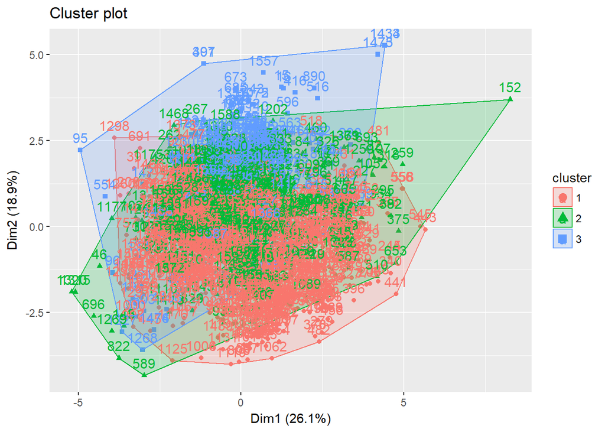

```r
distance <- dist(wine, method = "euclidean")
cluster_3 <- kmeans(distance, 3, nstart = 25)
fviz_cluster(cluster_3, data = wine)
```

## Complete Linkage

```r
hclust_gap <- clusGap(wine, FUN = hcut, nstart = 25, K.max = 10, B = 50)
```

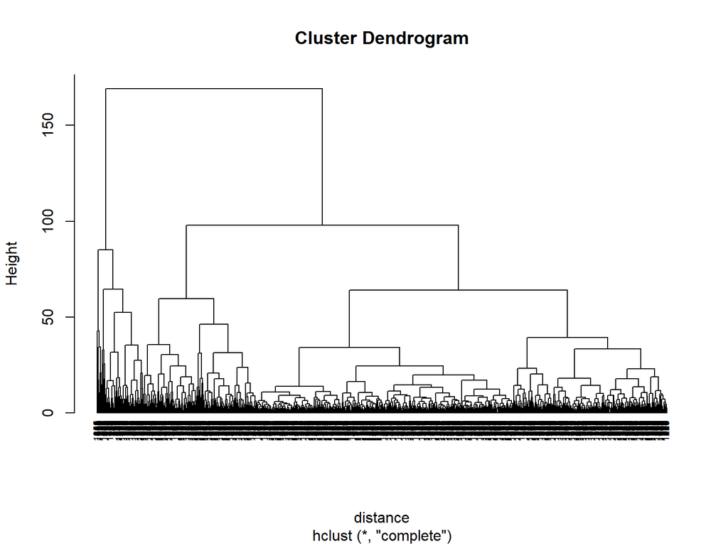

```r
distance <- dist(wine, method = "euclidean")
complete_linkage <- hclust(distance, method = "complete" )
plot(complete_linkage, cex = 0.6, hang = -1)
```

```r
time <- mean(microbenchmark(hclust(distance, method = "complete" ), unit = "s" )$time*1e-9)
time
```

```
## [1] 0.06135893
```

The amount of time it took to execute the `hclust()` function on our dataset was 0.061 seconds.

**Note that there is not a way to specify our `K` parameter in the `hclust()` function.**

## Remarks

$\quad$ Both functions `kmeans()` and `hclust()` perform fairly quickly and our concept of $O(n)$ was demonstrated fairly well. Runtime does indeed increase with greater `K` and `# of Iterations`

# SAS

## Import/Clean data

First, we will read the wine quality data into SAS and do a little bit of data cleaning to avoid our results being skewed by outlying data.

`

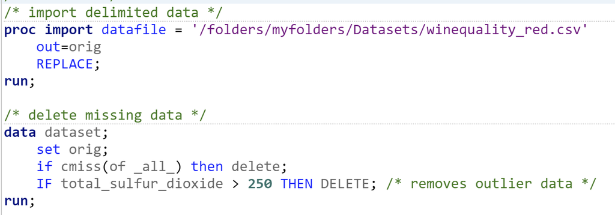

$\quad$ In our clustering methods, the following variables will be treated as predictors for the response categorical wine quality (on scale of 3-8): fixed acidity, volatile acidity, citric acid, residual sugar, chlorides, free sulfur dioxide, total sulfur dioxide, density, pH, sulphates, alcohol.

$\quad$ In SAS, the runtimes for particular procedures can be viewed in the log file after code execution. They will be visible as “CPU time” in the images to come. As the primary focus, we will be comparing the execution times through this method.

## K-Means Performance:

`

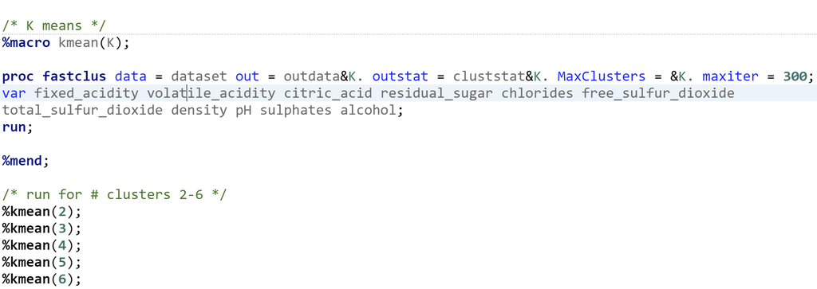

`

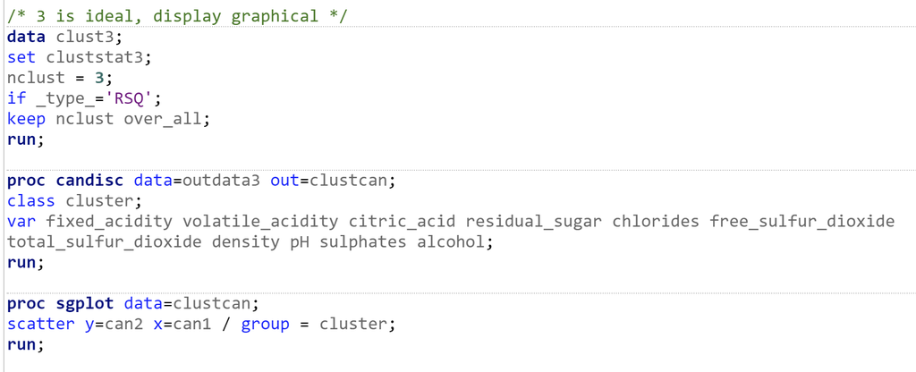

`

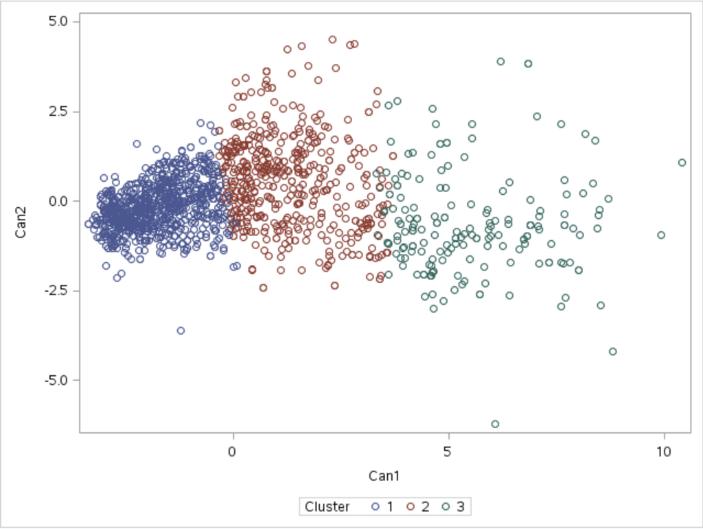

$\quad$ Below is an example of the output after code execution in SAS, which we can easily view the cpu runtime that we will treat as the runtime for the block of code. For our needs, this will be appropriately sufficient.

`

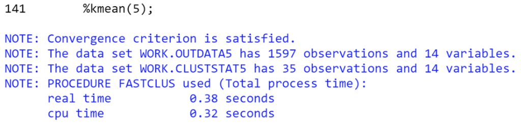

Runtimes are shown below, and easily comparable.

|  | CPU time (in seconds) |
| --- | --- |
| K = 2 | 0.32 |
| K = 3 | 0.28 |
| K = 4 | 0.30 |
| K = 5 | 0.32 |
| K = 6 | 0.32 |

## Complete Linkage

$\quad$ We display the syntax used for complete linkage, as well as runtime computed. There is extensive output in the tables generated to display the clustering assigned from the Hierarchical Clustering, which are not displayed for conciseness in light of the focus of the project: runtime.

`

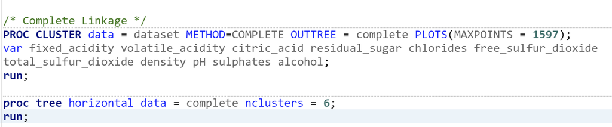

`

[figure not shown]

## Remarks

For k-means, there is not a strict clear increase in runtime as we increase the number of clusters.

$\quad$ For complete linkage, the runtime was 3.66 seconds, significantly longer than the various < 0.5 seconds of runtime from K-means. This is expected, as complete linkage is a much more complicated algorithm while K-Means is a much simpler and thus faster algorithm. We can somewhat reason this as we know complete linkage is based upon the following formula.

`

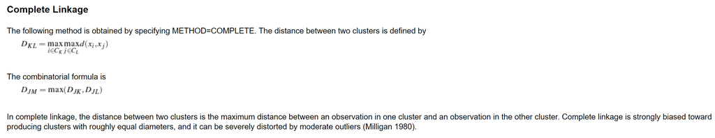

# Python

## Import/Clean data

```r
from sklearn.metrics import silhouette_score
from sklearn import metrics
from sklearn.cluster import *
import pandas as pd
import numpy as np
import time


wine = pd.read_csv('winequality-red.csv')
wine_y = wine.quality
wine_x = wine.drop('quality',1)
```

$\quad$ We will use time.clock to measure the runtime of different clusters. On Unix, time.clock returns the current processor time expressed in seconds, and on Windows, it returns the wall-clock time expressed in seconds elapsed since the first call to this function.

```r
cluster_time_kmeans = np.zeros(5)
cluster_time_Hierarchical = np.zeros(5)

for k in range(2,7):
    start = time.clock()
    cluster_k = KMeans(n_clusters = k).fit(wine_x)
    end = time.clock()
    cluster_time_kmeans[k-2] = end-start
    start = time.clock()
    cluster_k = AgglomerativeClustering(n_clusters = k,linkage = 'average').fit(wine_x)
    end = time.clock()
    cluster_time_Hierarchical[k-2] = end-start

cluster_time = pd.DataFrame({'Cluster_number': np.arange(2,7),'Kmeans':cluster_time_kmeans,'Hierarchical':cluster_time_Hierarchical})
cluster_time
```

Runtime (Seconds) for Kmeans and Hierarchical cluster

| Cluster_number | Hierarchical | Kmeans |
| --- | --- | --- |
| 2 | 0.167 | 0.069 |
| 3 | 0.119 | 0.053 |
| 4 | 0.093 | 0.087 |
| 5 | 0.101 | 0.097 |
| 6 | 0.088 | 0.076 |

Comments: Following is a plot to show our cluster results, and I choose k=3. Here I reduced the dimensions into 2 using PCA methods, and then make a scatter plot grouped by the three labels.

```r
from sklearn.decomposition import PCA as sklearnPCA
import matplotlib.pyplot as plt
pca = sklearnPCA(n_components=2) #2-dimensional PCA
kmeans=KMeans(n_clusters=3)
kmeansoutput=kmeans.fit(wine_x)
transformed = pd.DataFrame(pca.fit_transform(wine_x),index = kmeansoutput.labels_)

plt.scatter(transformed.loc[0][0], transformed.loc[0][1], label='Class 1', c='red')
plt.scatter(transformed.loc[1][0], transformed.loc[1][1], label='Class 2', c='blue')
plt.scatter(transformed.loc[2][0], transformed.loc[2][1], label='Class 3', c='lightgreen')

plt.legend()
plt.title('scatter plot for kmeans with 3 clusters')
plt.show()
```

`

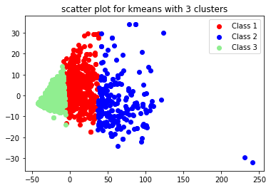

## Remarks

$\quad$ For Kmeans and Hierarchical cluster method respectively, runtime is not strictly depend on the cluster number. And for all cluster number, Kmeans runs a little faster than Hierarchical cluster.

# Conclusion